# ARIMAX/SARIMAX for Consumer Staples Sector Fund and macroeconomic factors

##### Fitting a ARIMAX model

Fitting an ARIMAX model will be a useful approach to modeling and predicting time series data when external factors are believed to have an impact on the response variable. In this case, we will be using an ARIMAX model to predict the Consumer Staples Sector Fund Stock Price, taking into account the effects of inflation on the sector. By including these exogenous variables in our model, we can improve the accuracy of our predictions and gain a better understanding of the underlying dynamics of the time series.

**Auto ARIMA**

```r
xreg <- cbind(Inflation = normalized_XLP_factor_data_ts[, "inflation"])

fit <- auto.arima(normalized_XLP_factor_data_ts[, "XLP.Adjusted"], xreg = xreg)
summary(fit)
```

```
Series: normalized_XLP_factor_data_ts[, "XLP.Adjusted"]
Regression with ARIMA(0,1,0) errors

Coefficients:
        xreg
      0.5390
s.e.  0.2455

sigma^2 = 0.15:  log likelihood = -7.48
AIC=18.96   AICc=19.82   BIC=20.63

Training set error measures:
                     ME     RMSE       MAE      MPE    MAPE      MASE
Training set 0.05960426 0.365138 0.3186148 7.758641 72.3286 0.4301663
                    ACF1
Training set 0.005736426
```

**Residuals**

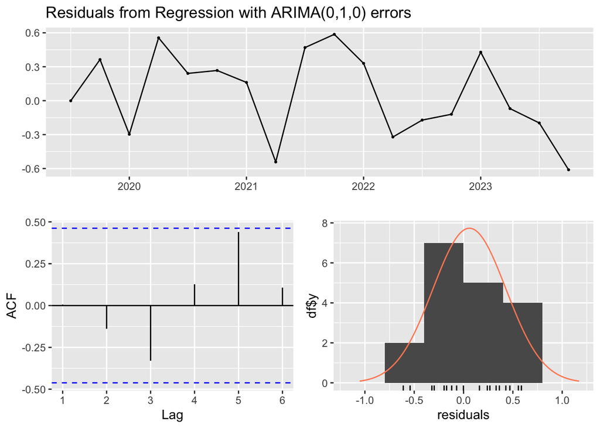

```
    Ljung-Box test

data:  Residuals from Regression with ARIMA(0,1,0) errors
Q* = 3.4594, df = 4, p-value = 0.4841

Model df: 0.   Total lags used: 4
```

```r
checkresiduals(fit)
```

##### Fitting the model manually

**Linear Model**

```r
normalized_XLP_factor_data_numeric_df$XLP.Adjusted<-ts(normalized_XLP_factor_data_numeric_df$XLP.Adjusted,star=decimal_date(as.Date("2018-07-01",format = "%Y-%m-%d")),frequency = 4)
normalized_XLP_factor_data_numeric_df$inflation<-ts(normalized_XLP_factor_data_numeric_df$inflation,star=decimal_date(as.Date("2018-07-01",format = "%Y-%m-%d")),frequency = 4)


############# First fit the linear model##########
fit.reg <- lm(XLP.Adjusted ~ inflation, data=normalized_XLP_factor_data_numeric_df)
summary(fit.reg)
```

```
Call:
lm(formula = XLP.Adjusted ~ inflation, data = normalized_XLP_factor_data_numeric_df)

Residuals:
    Min      1Q  Median      3Q     Max
-1.0945 -0.3724  0.0981  0.2660  1.1861

Coefficients:
             Estimate Std. Error t value Pr(>|t|)
(Intercept) 3.255e-16  1.460e-01    0.00        1
inflation   7.993e-01  1.502e-01    5.32  6.9e-05 ***
---
Signif. codes:  0 '***' 0.001 '**' 0.01 '*' 0.05 '.' 0.1 ' ' 1

Residual standard error: 0.6194 on 16 degrees of freedom
Multiple R-squared:  0.6389,    Adjusted R-squared:  0.6163
F-statistic: 28.31 on 1 and 16 DF,  p-value: 6.9e-05
```

**ACF of Residuals**

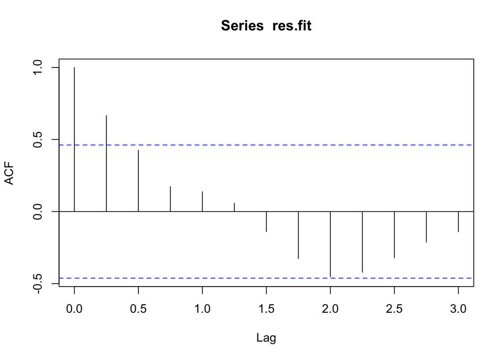

```r
res.fit<-ts(residuals(fit.reg),star=decimal_date(as.Date("2018-01-01",format = "%Y-%m-%d")),frequency = 4)
############## Then look at the residuals ############
acf(res.fit)
```

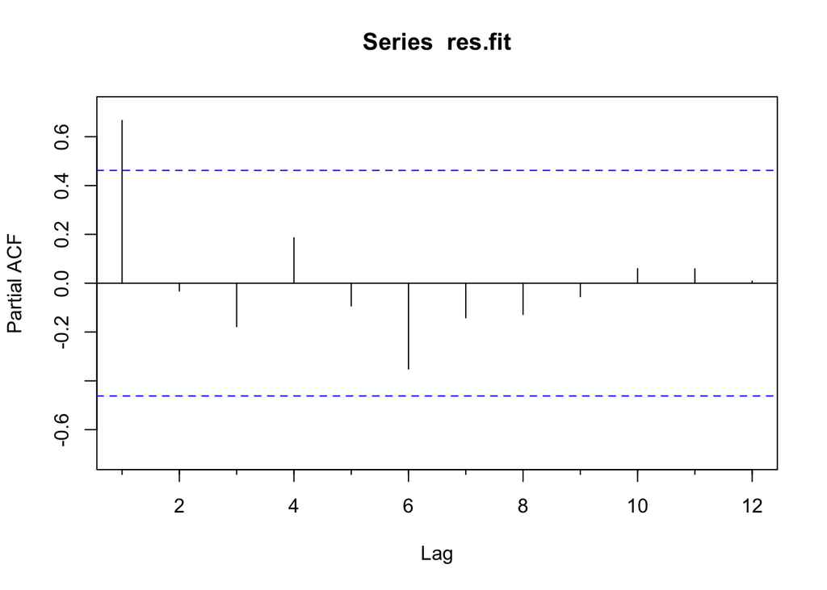

```r
Pacf(res.fit)
```

**Differentiated Residual**

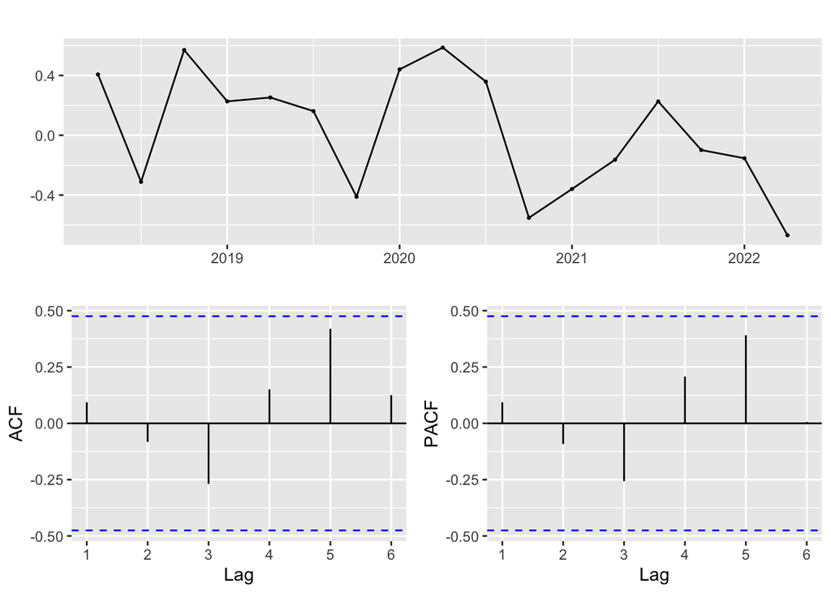

```r
res.fit %>% diff() %>% ggtsdisplay()
```

As both the model fitted manually and the auto.arima parameters are the same, i.e. p = 0, q = 0 and d = 1. We proceed with fitting the model for the parameters.

##### Model Fitting

**Model Plot**

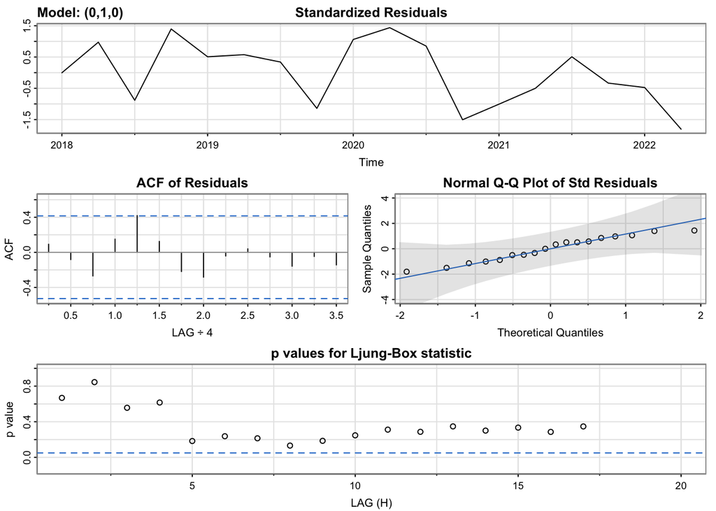

```r
set.seed(1234)

model_output <- capture.output(sarima(res.fit, 0,1,0))
```

**Model**

```r
cat(model_output[9:38], model_output[length(model_output)], sep = "\n")
```

```
$fit

Call:
arima(x = xdata, order = c(p, d, q), seasonal = list(order = c(P, D, Q), period = S),
    xreg = constant, transform.pars = trans, fixed = fixed, optim.control = list(trace = trc,
        REPORT = 1, reltol = tol))

Coefficients:
      constant
        0.0300
s.e.    0.0938

sigma^2 estimated as 0.1496:  log likelihood = -7.97,  aic = 19.95

$degrees_of_freedom
[1] 16

$ttable
         Estimate     SE t.value p.value
constant     0.03 0.0938  0.3203  0.7529

$AIC
[1] 1.1734

$AICc
[1] 1.189086

$BIC
[1] 1.271425
```

The best model identified is ARIMA(0,1,0). By analyzing the standardized residuals plot, it can be observed that the mean is close to 0. Deviations from these values could indicate poor model fit. However, in this case, the model seems to be well-fitted. The ACF plot of residuals shows very few significant lags, which is a positive sign for the model. The qq-plot also suggests normality in the residuals. Additionally, the p-values for the Ljung-Box test are greater than 0.05, indicating that the residuals are independent, which is favorable for the model’s accuracy.

##### Forecast

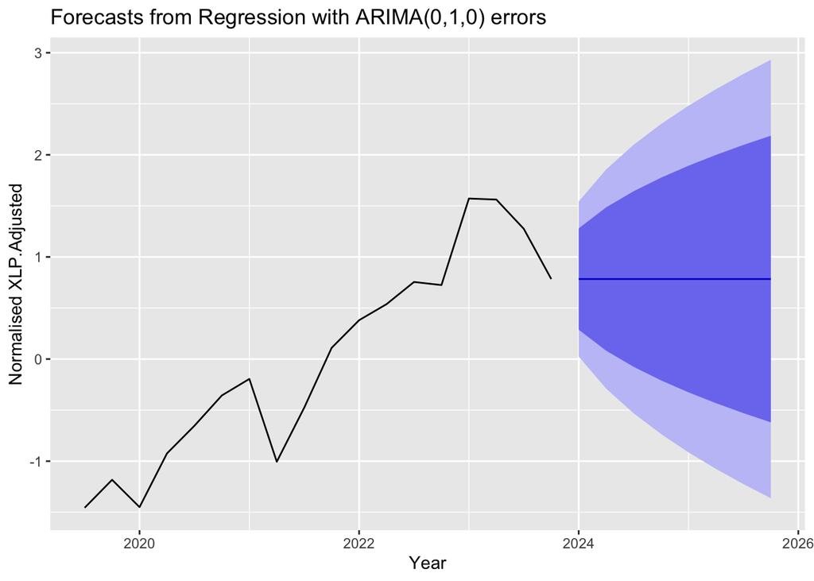

```r
#fiting an ARIMA model to the Inflation variable
inflation_fit<-auto.arima(normalized_XLP_factor_data_numeric_df$inflation)
finflation<-forecast(inflation_fit)


# best model fit for forcasting
xreg <- cbind(Inflation = normalized_XLP_factor_data_ts[, "inflation"])

fit <- Arima(normalized_XLP_factor_data_ts[, "XLP.Adjusted"],order=c(0,1,0),xreg=xreg)

# Forcast the stock price using feature variables
fxreg <- cbind(Inflation = finflation$mean)
fcast <- forecast(fit, xreg=fxreg)
autoplot(fcast) + xlab("Year") +
  ylab("Normalised XLP.Adjusted")
```

### ARIMA Model for Inflation

```r
#fiting an ARIMA model to the Inflation variable
inflation_fit<-auto.arima(normalized_XLP_factor_data_numeric_df$inflation)
finflation<-forecast(inflation_fit)
summary(inflation_fit)
```

```
Series: normalized_XLP_factor_data_numeric_df$inflation
ARIMA(0,1,0)

sigma^2 = 0.1378:  log likelihood = -7.28
AIC=16.55   AICc=16.82   BIC=17.38

Training set error measures:
                    ME      RMSE       MAE       MPE     MAPE      MASE
Training set 0.1201871 0.3607553 0.2312026 -26.91442 61.15158 0.2676132
                  ACF1
Training set 0.2431721
```

### ARIMA Model for Consumer Staples Sector Fund with feature variable

```r
# best model fit for forcasting
xreg <- cbind(Inflation = normalized_XLP_factor_data_ts[, "inflation"])

fit <- Arima(normalized_XLP_factor_data_ts[, "XLP.Adjusted"],order=c(0,1,0),xreg=xreg)
summary(fit)
```

```
Series: normalized_XLP_factor_data_ts[, "XLP.Adjusted"]
Regression with ARIMA(0,1,0) errors

Coefficients:
        xreg
      0.5390
s.e.  0.2455

sigma^2 = 0.15:  log likelihood = -7.48
AIC=18.96   AICc=19.82   BIC=20.63

Training set error measures:
                     ME     RMSE       MAE      MPE    MAPE      MASE
Training set 0.05960426 0.365138 0.3186148 7.758641 72.3286 0.4301663
                    ACF1
Training set 0.005736426
```